# Analyzing Financial and Economic Data with R

Chapter 07 - Basic Object Classes

Marcelo S. Perlin

2020-02-15

# Introduction

In this chapter, we will study R’s basic object classes with depth, including the manipulation of their content. It includes the following types of objects:

- Numeric (`numeric`)
- Text (`character`)
- Factors (`factor`)
- Logical Values (`logical`)
- Dates and Time (`Date` and `timedate`)
- Missing Data (`NA`)

# `Numeric` Objects

The objects of type `numeric` represent quantities and, unsurprisingly, are one of the most used objects in data research.

### Creating and Manipulating `numeric` Objects

It is easy to create and manipulate the `numeric` objects. As expected, we can use the common symbols of mathematical operations, such as sum (`+`), difference (`-`), division (`/`) and multiplication (`*`).

When working with `numeric` vectors, all mathematical operations are carried out using an **element by element** orientation and using vector notation.

```r
# create numeric vectors
x <- 1:5
y <- 2:6

# print sum
print(x+y)
```

```
## [1]  3  5  7  9 11
```

```r
# print multiplication
print(x*y)
```

```
## [1]  2  6 12 20 30
```

```r
# print division
print(x/y)
```

```
## [1] 0.5000000 0.6666667 0.7500000 0.8000000 0.8333333
```

```r
# print exponentiation
print(x^y)
```

```
## [1]     1     8    81  1024 15625
```

The difference between R and other programming languages is that operations between vectors of different sizes are accepted.

```r
# set x with 4 elements and y with 2
x <- 1:4
y <- 2:1

# print multiplication
print(x + y)
```

```
## [1] 3 3 5 5
```

The result of `x + y` is equivalent to `1:4 + c(2, 1, 2, 1)`.

Elements of a `numeric` vector can also be named. See an example next, where we create a vector with several named items.

```r
# create named vector
x <- c(item1 = 10,
       item2 = 14,
       item3 = 9,
       item4 = 2)

# print it
print(x)
```

```
## item1 item2 item3 item4
##    10    14     9     2
```

### Creating a `numeric` Sequence

In R, you have two ways to create a sequence of numerical values. The first with operator `:` as in `my_seq <- 1:10`. This method is practical because the notation is clear and direct.

A more powerful version for the creation of sequences is the use of function `seq.`

```r
# create sequence with seq
my_seq <- seq(from = -10,
              to = 10,
              by = 2)

# print it
print(my_seq)
```

```
##  [1] -10  -8  -6  -4  -2   0   2   4   6   8  10
```

Another interesting feature of function `seq` is the possibility of creating equally spaced vectors with an initial value, a final value, and the desired number of elements.

```r
# create sequence with defined number of elements
desired_len <- 20
my_seq <- seq(from = 0,
              to = 10,
              length.out = desired_len)

# print it
print(my_seq)
```

```
##  [1]  0.0000000  0.5263158  1.0526316  1.5789474  2.1052632  2.6315789
##  [7]  3.1578947  3.6842105  4.2105263  4.7368421  5.2631579  5.7894737
## [13]  6.3157895  6.8421053  7.3684211  7.8947368  8.4210526  8.9473684
## [19]  9.4736842 10.0000000
```

The final number of elements in object `my_seq` is exactly 20. Function `seq` automatically calculates and sets the difference of 0.5263 between the adjacent elements.

### Creating Vectors with Repeated Elements

Another way to create `numeric` vectors is by using repetition.

```r
# repeat vector three times
my_x <- rep(x = 1, times = 10)

# print it
print(my_x)
```

```
##  [1] 1 1 1 1 1 1 1 1 1 1
```

It also works with vectors. For example, let’s say you need to create a vector with the repeated values of `c(1, 2)`. The result should be equal to `c(1, 2, 1, 2, 1, 2)`. For that, we use `rep` the same way:

```r
# created a vector with repeated elements
my_x <- rep(x = c(1, 2),
            times = 3)

# print it
print(my_x)
```

```
## [1] 1 2 1 2 1 2
```

### Creating Vectors with Random Numbers

Function `rnorm` generates random numbers from the Normal distribution, with options for the mean and standard deviation. The `mean` will set the point with the highest frequency and `sd` (standard deviation) will change the dispersion of the histogram.

```r
library(tidyverse)
# generate 10 random numbers from a Normal distribution
my_rnd_vec <- rnorm(n = 10000,
                    mean = 0,
                    sd = 1)

# print it
glimpse(my_rnd_vec)
```

```
##  num [1:10000] -1.409 1.109 0.066 -0.323 -0.105 ...
```

We generated ten thousand random numbers from a Normal distribution, with mean zero and standard deviation equal to one. Let’s see if its distribution of numbers looks close to the Normal, a bell shaped distribution:

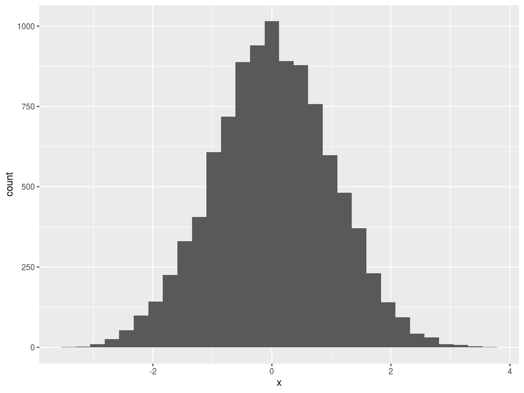

```r
p <- ggplot(tibble(x = my_rnd_vec), aes(x = x)) +
  geom_histogram()

print(p)
```

Yes, it is pretty close. You can change the parameters `mean` and `sd` for different shapes of a Normal distribution.

Function `runif` generates random values uniformly distributed between a maximum and a minimum.

```r
# create a random vector with minimum and maximum
my_rnd_vec <- runif(n = 10,
                    min = -5,
                    max = 5)

# print it
print(my_rnd_vec)
```

```
##  [1] -1.5482312 -3.8641854  3.3141156  0.9576968  2.0249665 -0.3087305
##  [7]  4.7772406 -2.1573012 -3.8385482 -3.9555131
```

Note that both functions, `rnorm` and `runif,` are limited to their respective distribution. An alternative and flexible way to generate random values is to use the `sample` function.

```r
# create sequence
my_vec <- seq(from = 0, to = 25, by=5)

# sample sequence
my_rnd_vec <- sample(my_vec)

# print it
print(my_rnd_vec)
```

```
## [1]  5  0 20 25 10 15
```

Function `sample` also allows the random selection of a fixed number of elements. If we wanted to select only one element of `my_vec` randomly, we could write the code as:

```r
# sample one element of my_vec
my_rnd_vec <- sample(my_vec, size = 1)

# print it
print(my_rnd_vec)
```

```
## [1] 0
```

If we wanted two random elements from `my_rnd_vec`:

```r
# sample two elements of my_vec
my_rnd_vec <- sample(my_vec, size = 2)

# print it
print(my_rnd_vec)
```

```
## [1] 0 5
```

### Accessing the Elements of a `numeric` Vector

All elements of a numerical vector can be accessed with brackets (`[]`). For example, if we wanted only the first element of `x,` we can use `x[1]`:

```r
# set vector
x <- c(-1, 4, -9, 2)

# get first element
first_elem_x <- x[1]

# print it
print(first_elem_x)
```

```
## [1] -1
```

The same notation is used to extract parts of a vector. If we wanted to create a sub-vector with the first and second element of `x,` we can achieve this goal with the next chunk of code:

```r
# sub-vector of x
sub_x <- x[1:2]

# print it
print(sub_x)
```

```
## [1] -1  4
```

To access named elements of a numeric array, simply use its name as a `character` value or vector inside the brackets.

```r
# set named vector
x <- c(item1 = 10, item2 = 14, item3 = -9, item4 = -2)

# access elements by name
print(x['item2'])
```

```
## item2
##    14
```

```r
print(x[c('item2','item4')])
```

```
## item2 item4
##    14    -2
```

### Modifying and Removing Elements of a `numeric` Vector

The modification of a vector is very simple. Just indicate the changes with the *assign* symbol (`<-`):

```r
# set vector
my_x <- 1:4

# modify first element to 5
my_x[1] <- 5

# print result
print(my_x)
```

```
## [1] 5 2 3 4
```

This modification can also be performed block-wise:

```r
# set vector
my_x <- 0:5

# set the first three elements to 5
my_x[1:3] <- 5

# print result
print(my_x)
```

```
## [1] 5 5 5 3 4 5
```

Using conditions to change values in a vector is also possible:

```r
# set vector
my_x <- -5:5

# set any value lower than 2 to 0
my_x[my_x<2] <- 0

# print result
print(my_x)
```

```
##  [1] 0 0 0 0 0 0 0 2 3 4 5
```

The removal of elements of a vector is carried out using a negative index:

```r
# create vector
my_x <- -5:5

# remove first and second element of my_x
my_x <- my_x[-(1:2)]

# show result
print(my_x)
```

```
## [1] -3 -2 -1  0  1  2  3  4  5
```

Notice how using negative index simply returns the original vector, without the elements in the brackets.

# `Character` Objects

The `character` class, or simply text class, is used to store textual information.

### Creating a Simple `character` Object

In R, every `character` object is created by encapsulating a text with double quotation marks (" ") or single (’ ’).

```r
tickers <- c('MMM', 'FB', 'ICE')
print(tickers)
```

```
## [1] "MMM" "FB"  "ICE"
```

We can confirm the class of the created object with function `class`:

```r
class(tickers)
```

```
## [1] "character"
```

### Creating Structured `character` Objects

We can also use R to create a text vector with some sort of structure. For example, vector `c('ticker 1', 'ticker 2', ..., 'ticker 19', 'ticker 20')` has a clear logic. It combines a text `ticker` with values from a vector that starts in 1 and ends in 20.

```r
library(stringr)

# create sequence and tex
my_seq <- 1:20
my_text <- 'text'

# paste objects together (without space)
my_char <- str_c(my_text, my_seq)
print(my_char)
```

```
##  [1] "text1"  "text2"  "text3"  "text4"  "text5"  "text6"  "text7"  "text8"
##  [9] "text9"  "text10" "text11" "text12" "text13" "text14" "text15" "text16"
## [17] "text17" "text18" "text19" "text20"
```

```r
# paste objects together (with space)
my_char <- str_c(my_text,
                 my_seq,
                 sep = ' ')
print(my_char)
```

```
##  [1] "text 1"  "text 2"  "text 3"  "text 4"  "text 5"  "text 6"  "text 7"
##  [8] "text 8"  "text 9"  "text 10" "text 11" "text 12" "text 13" "text 14"
## [15] "text 15" "text 16" "text 17" "text 18" "text 19" "text 20"
```

We can do the same procedure with text vectors:

```r
# set character value
my_x <- 'My name is'

# set character vector
my_names <- c('Marcelo', 'Ricardo', 'Tarcizio')

# paste and print
print(str_c(my_x, my_names, sep = ' '))
```

```
## [1] "My name is Marcelo"  "My name is Ricardo"  "My name is Tarcizio"
```

### Selecting Pieces of a Text Object

A common beginner’s mistake is to select characters of a text using brackets, as it is done for selecting elements of a vector. Consider the following code:

```r
# set char object
my_char <- 'ABCDE'

# print its second element (WRONG - RESULT is NA)
print(my_char[2])
```

```
## [1] NA
```

The `NA` value indicates the second element of `my_char` does not exist. This happens because using square brackets is reserved for accessing the elements of an atomic vector, not characters within a larger text. Watch what happens when we use `my_char[1]`:

```r
print(my_char[1])
```

```
## [1] "ABCDE"
```

The result is simply the *ABCDE* text, on the first item of `my_char`. To select pieces of text, we need to use function `stringr::str_sub` or `base::substr`:

```r
# print third and fourth characters
my_substr <- str_sub(string = my_char,
                     start = 2,
                     end = 2)
print(my_substr)
```

```
## [1] "B"
```

These functions also work for atomic vectors. Let’s assume you imported text data, and the raw dataset contains a 3-letter identifier of a company, always in the same location of the string. Let’s simulate the situation in R:

```r
# build char vec
my_char_vec <- paste0(c('ABC','VBC','ZMN'),
                      ' - other ignorable text')
print(my_char_vec)
```

```
## [1] "ABC - other ignorable text" "VBC - other ignorable text"
## [3] "ZMN - other ignorable text"
```

Here, we want the information in the first three characters of each element only in `my_char_vec.` To select them, we can use the same functions as before.

```r
# get ids with stringr::str_sub
ids_vec <- str_sub(my_char_vec, 1, 3)
print(ids_vec)
```

```
## [1] "ABC" "VBC" "ZMN"
```

**Vector operations in character objects are very common in R**. Almost anything you can do to a single element can be expanded to vectors. This facilitates the development of research scripts as you can easily perform complicated tasks to a series of elements in a single line of code.

### Finding and Replacing Characters of a Text

A useful operation in handling texts is to locate specific patterns of text within a `character` object with functions `stringr::str_locate`/`base::regexpr` and `stringr::str_locate_all`/`base::gregexpr`.

The following example shows how to find the *D* character from a range of characters.

```r
# set character object
my_char <- 'ABCDEF-ABCDEF-ABC'

# find position of 'D' using str_locate
pos <- str_locate(my_char, fixed('D'))
print(pos)
```

```
##      start end
## [1,]     4   4
```

Note the `str_locate` function returns only the **first occurrence** of *D*. To locate all instances, we use function `str_locate_all`.

```r
# set object
my_char <- 'ABCDEF-ABCDEF-ABC'

# find position of ALL 'D' using str_locate_all
pos <- str_locate_all(my_char, fixed('D'))
print(pos)
```

```
## [[1]]
##      start end
## [1,]     4   4
## [2,]    11  11
```

To replace characters in a text, use functions `str_replace` and `str_replace_all` from `stringr` or `sub` and `gsub` from the base package.

```r
# set char object
my_char <- 'ABCDEF-ABCDEF-ABC'

# substitute the FIRST 'ABC' for 'XXX' with str_replace
my_char <- str_replace(string = my_char,
                       pattern = 'ABC',
                       replacement = 'XXX')
print(my_char)
```

```
## [1] "XXXDEF-ABCDEF-ABC"
```

And now, we globally substitute characters.

```r
# set char object
my_char <- 'ABCDEF-ABCDEF-ABC'

# substitute ALL 'ABC' for 'XXX' with str_replace_all
my_char <- str_replace_all(string = my_char,
                           pattern = 'ABC',
                           replacement = 'XXX')

# print result
print(my_char)
```

```
## [1] "XXXDEF-XXXDEF-XXX"
```

Again, it is worth pointing out that the operations of replacements of strings also work for vectors. Have a look at the next example.

```r
# set char object
my_char <- c('ABCDEF','DBCFE','ABC')

# create an example of vector
my_char_vec <- paste(sample(my_char, 5, replace = T),
                     sample(my_char, 5, replace = T),
                     sep = ' - ')

# show it
print(my_char_vec)
```

```
## [1] "DBCFE - ABCDEF"  "ABCDEF - DBCFE"  "DBCFE - DBCFE"   "ABCDEF - ABCDEF"
## [5] "ABC - ABCDEF"
```

```r
# substitute all occurrences of 'ABC'
my_char_vec <- str_replace_all(string = my_char_vec,
                               pattern = 'ABC',
                               replacement = 'XXX')

# print result
print(my_char_vec)
```

```
## [1] "DBCFE - XXXDEF"  "XXXDEF - DBCFE"  "DBCFE - DBCFE"   "XXXDEF - XXXDEF"
## [5] "XXX - XXXDEF"
```

### Splitting Text

Eventually, you will need to break a text into different parts.

```r
# set char
my_char <- 'ABC;ABC;BCD'

# split it based on ';' and using stringr::str_split
splitted_char <- str_split(my_char, ';')

# print result
print(splitted_char)
```

```
## [[1]]
## [1] "ABC" "ABC" "BCD"
```

The output of this function is an object of type `list`. To access the text `BCD` in object `splitted_char,` we can use the following code:

```r
print(splitted_char[[1]][3])
```

```
## [1] "BCD"
```

For an example of a split in character vectors, see the next code.

```r
# set char
my_char_vec <- c('ABCDEF','DBCFE','ABFC','ACD')

# split it based on 'B' and using stringr::strsplit
splitted_char <- str_split(my_char_vec, 'B')

# print result
print(splitted_char)
```

```
## [[1]]
## [1] "A"    "CDEF"
##
## [[2]]
## [1] "D"   "CFE"
##
## [[3]]
## [1] "A"  "FC"
##
## [[4]]
## [1] "ACD"
```

Notice how, again, an object of type `list` is returned, where each element is the split text from the input vector.

### Finding the Number of Characters in a Text

If we want to discover the number of characters in a `character` object, you can use functions `stringr::str_length` and `base::nchar`.

```r
# set char
my_char <- 'abcdef'

# print number of characters using stringr::str_length
print(str_length(my_char))
```

```
## [1] 6
```

And now an example with vectors.

```r
#set char
my_char <- c('a', 'ab', 'abc')

# print number of characters using stringr::str_length
print(str_length(my_char))
```

```
## [1] 1 2 3
```

### Generating Combinations of Text

One useful trick in R is to use functions `outer` and `expand.grid` to create all possible combinations of elements in different objects.

```r
# set char vecs
my_vec_1 <- c('a','b')
my_vec_2 <- c('A','B')

# combine in matrix
comb_mat <- outer(my_vec_1, my_vec_2, paste, sep='-')

# print it!
print(comb_mat)
```

```
##      [,1]  [,2]
## [1,] "a-A" "a-B"
## [2,] "b-A" "b-B"
```

The output of `outer` is a `matrix` type of object. If we wanted to change `comb_mat` to an atomic vector, we can use function `as.character`:

```r
print(as.character(comb_mat))
```

```
## [1] "a-A" "b-A" "a-B" "b-B"
```

Another way to reach the same objective is by using function `expand.grid.` Look at the next example, where we create different phrases based on all combinations of character vectors.

```r
library(tidyverse)

# set vectors
my_vec_1 <- c('John ', 'Claire ', 'Adam ')
my_vec_2 <- c('is fishing.', 'is working.')

# create df with all combinations
my_df <- expand.grid(name = my_vec_1,
                     verb = my_vec_2)

# print df
print(my_df)
```

```
##      name        verb
## 1   John  is fishing.
## 2 Claire  is fishing.
## 3   Adam  is fishing.
## 4   John  is working.
## 5 Claire  is working.
## 6   Adam  is working.
```

```r
# paste columns together in tibble
my_df <- my_df %>%
  mutate(phrase = paste0(name, verb) )

# print result
print(my_df)
```

```
##      name        verb             phrase
## 1   John  is fishing.   John is fishing.
## 2 Claire  is fishing. Claire is fishing.
## 3   Adam  is fishing.   Adam is fishing.
## 4   John  is working.   John is working.
## 5 Claire  is working. Claire is working.
## 6   Adam  is working.   Adam is working.
```

Here, we used the function `expand.grid` to create a `dataframe` containing all possible combinations of `my_vec_1` and `my_vec_2`. We pasted the contents of these columns using `paste0`.

# `Factor` Objects

Object class `factor` is used to represent groups (categories) in a database.

It integrates nicely with statistical procedures and packages, so the work of dealing with groups becomes easier.

### Creating `factors`

The creation of factors is accomplished with function `factor`:

```r
# create factor
my_factor <- factor(c('M', 'F', 'M',
                      'M', 'F', 'F'))

# print it
print(my_factor)
```

```
## [1] M F M M F F
## Levels: F M
```

Notice that, in the previous example, the presentation of factors with function `print` shows its content and an extra item called `Levels,` which identifies the possible groups in the object, in this case, only `M` and `F.`

### Modifying `factors`

An important point about the `factor` type of objects is their `Levels` are immutable and will not update with the input of new data. You cannot modify the `Levels` after the creation of a `factor.` All new groups not in the `Levels` will be transformed into `NA` (*not available* ) and a `warning` message will appear on the screen.

```r
# set factor
my_factor <- factor(c('a', 'b', 'a', 'b'))

# change first element of a factor to 'c'
my_factor[1] <- 'c'
```

```
## Warning in `[<-.factor`(`*tmp*`, 1, value = "c"): invalid factor level, NA
## generated
```

```r
# print result
print(my_factor)
```

```
## [1] <NA> b    a    b
## Levels: a b
```

As we expected, the first element of `my_factor` becomes an `NA.` Here, the proper way to add a new factor is to first transform the `factor` object to a `character` object, change the content and, finally, change the class back from `character` to `factor.`

```r
# set factor
my_factor <- factor(c('a', 'b', 'a', 'b'))

# change factor to character
my_char <- as.character(my_factor)

# change first element
my_char[1] <- 'c'

# mutate it back to class factor
my_factor <- factor(my_char)

# show result
print(my_factor)
```

```
## [1] c b a b
## Levels: a b c
```

Using these steps, we have the desired result in vector `my_factor,` with three `Levels`: `a,` `b` and `c.`

The `tidyverse` universe also has its own package for handling factors: `forcats.` For the current factor modification problem, we can use `forcats::fct_recode` function. Here’s an example where we change the values of factors and levels:

```r
library(forcats)

# set factor
my_factor <- factor(c('A', 'B', 'C',
                      'A', 'C', 'M',
                      'N'))

# modify factors
my_factor <- fct_recode(my_factor,
                        'D' = 'A',
                        'E' = 'B',
                        'F' = 'C')

# print result
print(my_factor)
```

```
## [1] D E F D F M N
## Levels: D E F M N
```

Using `forcats::fct_recode` is intuitive. All we need to do is to set the new names with the equality symbol.

### Converting `factors` to Other Classes

Attention is required when converting a `factor` to another class. When converting a `factor` to the `character` class, the result is as expected:

```r
# create factor
my_char <-factor(c('a', 'b', 'c'))

# convert and print
print(as.character(my_char))
```

```
## [1] "a" "b" "c"
```

However, when the same procedure is performed for conversion from `factor` to the `numeric` class, the result is far from expected:

```r
# set factor
my_values <- factor(5:10)

# convert to numeric (WRONG)
print(as.numeric(my_values))
```

```
## [1] 1 2 3 4 5 6
```

Solving this problem and getting the result we want is easy; just turn the `factor` object into a `character` and then to `numeric,` as shown next:

```r
# converting factors to character and then to numeric
print(as.numeric(as.character(my_values)))
```

```
## [1]  5  6  7  8  9 10
```

As we can see, now we got the result we expected. As a rule of thumb, **always be careful when transforming factors into numbers**.

### Creating Contingency Tables

After creating a factor, we can find the number of times that each group, or combination of groups, is found with function `table`.

```r
# create factor
my_factor <- factor(sample(c('Pref', 'Ord'),
                           size = 20,
                           replace = TRUE))

# print contingency table
print(table(my_factor))
```

```
## my_factor
##  Ord Pref
##    8   12
```

A more advanced usage of function `table` is to consider more than one `factor`:

```r
# set factors
my_factor_1 <- factor(sample(c('Pref', 'Ord'),
                             size = 20,
                             replace = TRUE))

my_factor_2 <- factor(sample(paste('Grupo', 1:3),
                             size = 20,
                             replace = TRUE))

# print contingency table with two factors
print(table(my_factor_1,
            my_factor_2))
```

```
##            my_factor_2
## my_factor_1 Grupo 1 Grupo 2 Grupo 3
##        Ord        2       0       2
##        Pref       6       7       3
```

The table that we created previously demonstrates the number of occurrences for each combination of groups. Therefore, it is worth knowing you can also use it with more than two factors.

# `Logical` Objects

Logical tests are at the heart of R. In one line of code, and we can test a condition for a large vector of data.

### Creating `logical` Objects

Objects of class `logical` are created based on the use of condition tests on other objects. For example, in a sequence from 1 to 10, we can check what elements are higher than five with the following code:

```r
# set numerical
my_x <- 1:10

# print a logical test
print(my_x > 5)
```

```
##  [1] FALSE FALSE FALSE FALSE FALSE  TRUE  TRUE  TRUE  TRUE  TRUE
```

```r
# print position of elements from logical test
print(which(my_x > 5))
```

```
## [1]  6  7  8  9 10
```

In the previous example, function `which` returned the index (position) where the condition is true (`TRUE`).

To perform equality tests, simply use the equality symbol twice (**`==`**):

```r
# create char
my_char <- rep(c('abc', 'bcd'),
               times = 5)

# print its contents
print(my_char)
```

```
##  [1] "abc" "bcd" "abc" "bcd" "abc" "bcd" "abc" "bcd" "abc" "bcd"
```

```r
# print logical test
print(my_char == 'abc')
```

```
##  [1]  TRUE FALSE  TRUE FALSE  TRUE FALSE  TRUE FALSE  TRUE FALSE
```

For an inequality test, use symbol **`!=`**, as shown in the next code:

```r
# print inequality test
print(my_char != 'abc')
```

```
##  [1] FALSE  TRUE FALSE  TRUE FALSE  TRUE FALSE  TRUE FALSE  TRUE
```

It is also possible to test multiple logical conditions. For simultaneous occurrences of events, use operator `&.`

For example, if we wanted to check the values from a sequence between 1 and 10 that are larger than 4 **and** smaller than 7, we write:

```r
my_x <- 1:10

# print logical for values higher than 4 and lower than 7
print((my_x > 4)&(my_x < 7) )
```

```
##  [1] FALSE FALSE FALSE FALSE  TRUE  TRUE FALSE FALSE FALSE FALSE
```

```r
# print the actual values
idx <- which( (my_x > 4)&(my_x < 7) )
print(my_x[idx])
```

```
## [1] 5 6
```

For non-simultaneous conditions, i.e., the occurrence of one event or other, use the operator `|.`

```r
# location of elements higher than 7 or lower than 4
idx <- which( (my_x > 7)|(my_x < 4) )

# print elements from previous condition
print(my_x[idx])
```

```
## [1]  1  2  3  8  9 10
```

Another interesting use of logical objects is to test whether an item or more is found or not in another vector. For this, we use the operator `%in%`.

```r
library(dplyr)
# location of elements higher than 7 or lower than 4
my_contries <- c('Country 1', 'Country 2')

# set df
n_obs <- 100
df_temp <- tibble(country = str_c('Country ',
                                  sample(1:10,
                                         size = n_obs,
                                         replace = TRUE)),
                  inflation.rate = rnorm(n_obs, sd = 0.05) ) %>%
  glimpse()
```

```
## Observations: 100
## Variables: 2
## $ country        <chr> "Country 7", "Country 4", "Country 4", "Country 7", "C…
## $ inflation.rate <dbl> 0.0462839494, -0.0456405358, 0.0181461901, 0.031664895…
```

```r
# filter rows of df with selected tickers
df_temp <- df_temp %>%
  filter(country %in% my_contries) %>%
  glimpse()
```

```
## Observations: 18
## Variables: 2
## $ country        <chr> "Country 2", "Country 2", "Country 1", "Country 1", "C…
## $ inflation.rate <dbl> 0.0143392460, -0.0785901866, -0.0365106100, -0.0403645…
```

The resulting dataframe only has rows for `'Country 1'` and `'Country 2'`. With operator `%in%`, we filtered our table so it only keeps the desired rows.

# Date and Time

When you have dates in your dataset, you must be certain they are correctly represented in R with the correct timezone.

In this section, we will give priority to package `lubridate` [@lubridate], which offers efficient and diverse functions for time manipulation.

### Creating Simple Dates

The most basic class, indicating the day, month, and year, is `Date.` Using package `lubridate`, we create a date class object with functions `ymd` (year-month-date), `dmy` (day-month-year) e `mdy` (month-day-year). The order of components, and choice of function, is set according to the input character. Have a look:

```r
library(lubridate)
# set Date object (YMD)
print(ymd('2020-06-24'))
```

```
## [1] "2020-06-24"
```

```r
# set Date object (DMY)
print(dmy('24-06-2020'))
```

```
## [1] "2020-06-24"
```

```r
# set Date object (MDY)
print(mdy('06-24-2020'))
```

```
## [1] "2020-06-24"
```

Note that the functions return the exact same object. The difference in usage is only by the way the input string is structured with the position of the day, month, and year.

Now, using the `base` package, we can create a date with function `as.Date`:

```r
# set Date from dd/mm/yyyy with the definition of format
my_date <- as.Date('24/06/2020', format = '%d/%m/%Y')

# print result
print(my_date)
```

```
## [1] "2020-06-24"
```

The symbols used in *input* `format,` such as `%d,` `%m,` and `%Y,` indicate how the character object should be converted and where the day, month and year are in the text.

[output not shown]

By using the previous table, you’ll be able to create and represent dates in a vast number of ways. Notice how the `lubridate` functions, regarding `base,` are simpler and easier to use.

### Creating a Sequence of `Dates`

An interesting aspect of objects `Date` is they interact with `numeric` objects and can be used for logical tests.

If we wanted to add a day after a particular date, all we need to do is to add value 1 to the object, as shown next:

```r
# create date
my_date <- ymd('2020-06-01')

# find next day
my_date_2 <- my_date + 1

# print result
print(my_date_2)
```

```
## [1] "2020-06-02"
```

This property also works with vectors, facilitating the creation of `Date` sequences. See an example next.

```r
# create a sequence of Dates
my_date_vec <- my_date + 0:15

# print it
print(my_date_vec)
```

```
##  [1] "2020-06-01" "2020-06-02" "2020-06-03" "2020-06-04" "2020-06-05"
##  [6] "2020-06-06" "2020-06-07" "2020-06-08" "2020-06-09" "2020-06-10"
## [11] "2020-06-11" "2020-06-12" "2020-06-13" "2020-06-14" "2020-06-15"
## [16] "2020-06-16"
```

A more customizable way for creating `Date` sequences is using function `seq.`

```r
# set first and last Date
my_date_1 <- ymd('2017-03-07')
my_date_2 <- ymd('2017-03-20')

# set sequence
my_vec_date <- seq(from = my_date_1,
                   to = my_date_2,
                   by = '2 days')

# print result
print(my_vec_date)
```

```
## [1] "2017-03-07" "2017-03-09" "2017-03-11" "2017-03-13" "2017-03-15"
## [6] "2017-03-17" "2017-03-19"
```

Likewise, if we wanted a sequence of dates for every two weeks, we can simply change input `by` to `'2 weeks'`:

```r
# set first and last Date
my_date_1 <- ymd('2017-03-07')
my_date_2 <- ymd('2017-04-20')

# set sequence
my_vec_date <- seq(from = my_date_1,
                   to = my_date_2,
                   by = '2 weeks')

# print result
print(my_vec_date)
```

```
## [1] "2017-03-07" "2017-03-21" "2017-04-04" "2017-04-18"
```

Another way to use function `seq` is by setting the desired length of the sequence of dates. For example, if we wanted an array of dates with 10 elements, we would use:

```r
# set dates
my_date_1 <- as.Date('2020-06-27')
my_date_2 <- as.Date('2020-07-27')

# set sequence with 10 elements
my_vec_date <- seq(from = my_date_1,
                   to = my_date_2,
                   length.out = 10)

# print result
print(my_vec_date)
```

```
##  [1] "2020-06-27" "2020-06-30" "2020-07-03" "2020-07-07" "2020-07-10"
##  [6] "2020-07-13" "2020-07-17" "2020-07-20" "2020-07-23" "2020-07-27"
```

Once again, the interval between the dates is automatically defined by the function.

### Operations with `Dates`

We can calculate difference of days between two dates by simply subtracting one from the other. Have a look:

```r
# set dates
my_date_1 <- ymd('2015-06-24')
my_date_2 <- ymd('2020-06-24')

# calculate difference
diff_date <- my_date_2 - my_date_1

# print result
print(diff_date)
```

```
## Time difference of 1827 days
```

The output of the subtraction operation is an object of class `diffdate,` based on the `list` class. In the previous chapter, we mentioned that we could access the elements of a `list` using double brackets.

```r
# print difference of days as numerical value
print(diff_date[[1]])
```

```
## [1] 1827
```

Going further, we can also use mathematical operators to test whether a date is more recent or not than another:

```r
# set date and vector
my_date_1 <- ymd('2020-06-20')
my_date_vec <- ymd('2020-06-20') + seq(-5,5)

# test which elements of my_date_vec are older than my_date_1
my.test <- (my_date_vec > my_date_1)

# print result
print(my.test)
```

```
##  [1] FALSE FALSE FALSE FALSE FALSE FALSE  TRUE  TRUE  TRUE  TRUE  TRUE
```

The previous operation is useful when selecting a certain period of time in your dataset.

```r
library(dplyr)
library(lubridate)

# set first and last dates
first_date <- ymd('2020-06-01')
last_date <- ymd('2020-06-15')

# create dataframe and glimpse it
my_temp_df <- tibble(date.vec = ymd('2020-05-25') + seq(0,30),
                     prices=seq(1,10,
                                length.out = length(date.vec)))

# find dates that are between the first and last date
my_idx <- (my_temp_df$date.vec >= first_date) &
  (my_temp_df$date.vec <= last_date)

# use index to filter dataframe
my_temp_df_filtered <- my_temp_df %>%
  filter(my_idx) %>%
  glimpse()
```

```
## Observations: 15
## Variables: 2
## $ date.vec <date> 2020-06-01, 2020-06-02, 2020-06-03, 2020-06-04, 2020-06-05,…
## $ prices   <dbl> 3.1, 3.4, 3.7, 4.0, 4.3, 4.6, 4.9, 5.2, 5.5, 5.8, 6.1, 6.4, …
```

In the previous code, the object `my_temp_df_filtered` will only contain rows for the time period between 2020-06-01 and 2020-06-15.

### Dealing with Time

In R, the time/date format also follows the [ISO 8601 standard](https://www.iso.org/iso-8601-date-and-time-format.html)[^1] and is represented as “year-month-day hours:minutes:seconds timezone” (YYYY-MM-DD HH:mm:SS TMZ). See the following example:

```r
# creating a POSIXct object
my_timedate <- as.POSIXct('2020-01-01 16:00:00')

# print result
print(my_timedate)
```

```
## [1] "2020-01-01 16:00:00 -03"
```

The `lubridate` package also offers intelligent functions for creating date-time objects. These follow the same structural intuition as the date creation functions.

```r
library(lubridate)

# creating a POSIXlt object
my_timedate <- ymd_hms('2020-01-01 16:00:00')

# print it
print(my_timedate)
```

```
## [1] "2020-01-01 16:00:00 UTC"
```

You should note that this class automatically adds the time zone. If you need to represent a different time zone, you can do so with the `tz` argument:

```r
# creating a POSIXlt object with custom timezone
my_timedate_tz <- ymd_hms('2020-01-01 16:00:00',
                          tz = 'GMT')

# print it
print(my_timedate_tz)
```

```
## [1] "2020-01-01 16:00:00 GMT"
```

An important note in the case of `POSIXlt` and `POSIXct` objects, **the operations of sum and subtraction refer to seconds**, not days, as with objects from the `Date` class:

```r
# Adding values (seconds) to a POSIXlt object and printing it
print(my_timedate_tz + 30)
```

```
## [1] "2020-01-01 16:00:30 GMT"
```

### Extracting Elements of a Date

We can use function `format` to extract data elements such as the year, month, day, hour, minute and second.

```r
library(lubridate)

# create vector of date-time
my_datetime <- seq(from = ymd_hms('2020-01-01 12:00:00'),
                   to = ymd_hms('2020-01-01 18:00:00'),
                   by = '1 hour')

# get hours from POSIXlt
my_hours <- format(my_datetime, '%H')

# print result
print(my_hours)
```

```
## [1] "12" "13" "14" "15" "16" "17" "18"
```

Likewise, we can use symbols `%M` and `%S` to extract the hours, minutes and seconds of a `POSIXct` object:

```r
# create vector of date-time
n_dates <- 10
my_datetime <- seq(from = ymd_hms('2020-01-01 12:00:00'),
                   to = ymd_hms('2020-01-01 18:00:00'),
                   length.out = n_dates) + sample(1:59,
                                                  size = n_dates)

# get minutes from POSIXlt
my_minutes <- format(my_datetime, '%H:%M:%S')

# print result
print(my_minutes)
```

```
##  [1] "12:00:55" "12:40:53" "13:20:50" "14:00:01" "14:40:05" "15:20:58"
##  [7] "16:00:32" "16:40:02" "17:20:04" "18:00:11"
```

Alternatively, we can use `lubridate` functions such as `hour` and `minute`:

```r
# get hours with lubridate
print(hour(my_datetime))
```

```
##  [1] 12 12 13 14 14 15 16 16 17 18
```

```r
# get minutes with lubridate
print(minute(my_datetime))
```

```
##  [1]  0 40 20  0 40 20  0 40 20  0
```

Functions for extracting other components of a date, such as `lubridate::year` and `lubridate::second,` are also available.

### Find the Current Date and Time

If you want to find the present day, use function `base::Sys.Date` or `lubridate::today`

```r
library(lubridate)

# get today
print(Sys.Date())
```

```
## [1] "2020-02-26"
```

```r
# print it
print(today())
```

```
## [1] "2020-02-26"
```

If you want to find the current date and time, we use function `base::Sys.time` or `lubridate::now`:

```r
# get time!
print(Sys.time())
```

```
## [1] "2020-02-26 09:02:49 -03"
```

```r
# get time!
print(now())
```

```
## [1] "2020-02-26 09:02:49 -03"
```

Going further, based on these functions, we can write:

```r
# example of log message
my_sys_info <- Sys.info()
my_str <- str_c('Log of execution\n',
                'Time of execution: ', now(), '\n',
                'User: ', my_sys_info['user'], '\n',
                'Computer: ', my_sys_info['nodename'])

# print it
cat(my_str)
```

```
## Log of execution
## Time of execution: 2020-02-26 09:02:49
## User: msperlin
## Computer: Dell-Desktop
```

This is the exact time when this book was compiled in its final version. Notice we also got some details regarding username and computer with function `Sys.info.`

# Missing Data - `NA` (*Not available*)

One of the main innovations of R is the representation of missing data with objects of class `NA` (*Not Available*).

### Defining `NA` Values

To define omissions in the dataset, use symbol `NA` without quotes:

```r
# a vector with NA
my_x <- c(1, 2, NA, 4, 5)

# print it
print(my_x)
```

```
## [1]  1  2 NA  4  5
```

An important information that you must remember from previous chapters is that an `NA` object is contagious.

```r
# a vector
my_y <- c(2, 3, 5, 4, 1)

# example of NA interacting with other objects
print(my_x + my_y)
```

```
## [1]  3  5 NA  8  6
```

This property demands special attention if you are calculating a value recursively, such as when using functions `cumsum` and `cumprod.` In these cases, any value after `NA` will turn into `NA`:

```r
# set vector with NA
my_x <- c(1:5, NA, 5:10)

# print cumsum (NA after sixth element)
print(cumsum(my_x))
```

```
##  [1]  1  3  6 10 15 NA NA NA NA NA NA NA
```

```r
# print cumprod (NA after sixth element)
print(cumprod(my_x))
```

```
##  [1]   1   2   6  24 120  NA  NA  NA  NA  NA  NA  NA
```

Therefore, when using functions `cumsum` and `cumprod,` make sure no `NA` value is found in the input vector.

### Finding and Replacing `NA`

To find `NA` values, use function `is.na`:

```r
# set vector with NA
my_x <- c(1:2, NA, 4:10)

# Test and find location of NA
print(is.na(my_x))
```

```
##  [1] FALSE FALSE  TRUE FALSE FALSE FALSE FALSE FALSE FALSE FALSE
```

```r
print(which(is.na(my_x)))
```

```
## [1] 3
```

To replace it, use indexing with the output of `is.na`:

```r
# set vector
my_x <- c(1, NA, 3:4, NA)

# replace NA for 2
my_x[is.na(my_x)] <- 2

# print result
print(my_x)
```

```
## [1] 1 2 3 4 2
```

Another way to remove `NA` values is to use the function `na.omit,` which returns the same object, but without the `NA` values.

```r
# set vector
my_char <- c(letters[1:3], NA, letters[5:8])

# print it
print(my_char)
```

```
## [1] "a" "b" "c" NA  "e" "f" "g" "h"
```

```r
# use na.omit to remove NA
my_char <- na.omit(my_char)

# print result
print(my_char)
```

```
## [1] "a" "b" "c" "e" "f" "g" "h"
## attr(,"na.action")
## [1] 4
## attr(,"class")
## [1] "omit"
```

# Exercises

1. Let’s assume that, on a certain date, you bought 100 shares of a company, 15 dollars per share. After some time, you sold 30 shares for 18 dollars each and the remaining shares were sold for 22 dollars in a later day. Using a *script* in R, structure this financial problem by creating numeric objects. What is the gross profit of this stock market transaction?
2. Consider these numeric vectors `x` and `y`:

```r
set.seed(7)
x <- sample (1:3, size = 5, replace = T)
y <- sample (1:3, size = 5, replace = T)
```

What is the sum of the elements of a new vector resulting from the multiplication between the elements of x and y?

3. Create a sequence called `seq_1`, with values between -10 and 10, where the interval between elements is equal to 2.
4. Define another object named `seq_2`, which contains a sequence of length 1000, with values between 0 and 100.
5. Calculate the sum between `seq_1` and `seq_2`. Did this operation work despite the different sizes of the vectors? Explain your answer.
6. If we create an object with the cumulative sum of a sequence from 1 to 100, what is the position of the first element that exceeds the value of 50?
7. Create a vector according to the following formula, where $i=1 ... 100$. What is the value of the sum of the elements of x?

$$x_i = \frac{(-1^{i + 1})}{2i-1}$$

8. **CHALLENGE** - Create a $z_i$ vector according to the following formula, where $x_i = 1...50$ and $y_i = 50...1$. What is the value of the sum of $z_i$ elements? (TIP: see function `dplyr::lag`)

$$z_i = \frac{y_i-x_{i-1}}{y_{i-2}}$$

9. Create an object named `x` with 1000 random values taken from a Normal distribution with average and standard deviation equal to 10. Using the `cut` function, create another object that defines two groups based on values of `x,` one for values higher than 10, and another for values under -5. How many observations do we find in each group?
10. Execute the following code and create object `my_char`:

```r
set.seed(10)
my_char <- paste(sample(letters,
                        size =  500,
                        replace = T),
                 collapse = '')
```

How often is the letter `'x'` found in the resulting text object?

11. If we split the `my_char` object from the previous exercise into several smaller pieces of text using the letter `"b,"` what is the number of characters in the largest piece?
12. At link https://www.gutenberg.org/ebooks/2264.txt.utf-8, you can find a file containing the full text of William Shakespeare’s “Macbeth” book. Use the link directly with function `readr::read_lines` to import the entire book as a vector of characters called `my_book.` How many lines does the resulting object have?
13. Aggregate the vector of characters in `my_book` to a single text object named `full_text` using function `paste0(my_book, collapse = '\n')`. With functions from package `stringr,` check how often the word `'lord'` repeats itself throughout the text.
14. **CHALLENGE** - Use function `stringr::str_split` in object `full_text` to break the whole text as a function of whitespace (`' '`). Use this information with the function `base::table` and create a frequency table, showing the number of occurrences of each word. What are the five most used words in the text?
15. Assuming you’ll live for 100 years, what is the proportion of your birthdays that will land on a weekend day (Sunday/Saturday)? Tip: Use operator `%in%` to check a multiple equality condition.
[^1]: https://www.iso.org/iso-8601-date-and-time-format.html